# Tracking Thresholds for Hospital Admission Via Emergency Department

A Provider-level analysis  
DRAFT REPORT  
Autumn 2025

Authors

Affiliation

Steven Wyatt

The Strategy Unit

Andrew Jones

# Introduction

In this document, we propose methods, founded on statistical models, that would allow local areas to monitor whether casemix-adjusted admission thresholds are changing over time.[^1]

<sup>1</sup> For admissions via a hospital emergency department

We have imagined that such information might ultimately be incorporated in a simple software application (app). Using this app, a user might choose any one of 180 Type 1 (24 hour, consultant-led) emergency departments (EDs) and be shown how admission thresholds at that site are changing over time. The app could also include graphics and text summaries to illustrate how data quality and model design choices have influenced the trends they are shown.

# Methods

For each Type 1 ED, we aimed to show if, and by how much, thresholds for admission are changing over time. To achieve this, we fitted regression models to emergency care data to estimate the casemix-adjusted odds of admission for each week. The higher the odds of admission, the lower the admission threshold.

## Data source

This work relied on data from the Emergency Care Data Set (ECDS). Each ECDS record represents a patient attendance at an urgent or emergency care department. We selected the subset of records that were coded as unplanned attendances at Type 1 emergency departments, with an arrival date between 1st April 2025 and 19th October 2025 (inclusive).

We excluded records where the patient left the ED before treatment was provided; where the patient died during an attendance; and where the individual was found to be dead on arrival at the ED.

Table 1 provides an example of how these choices affect the number of emergency attendances included from a given provider (in this case Hull Royal Infirmary).

Table 1: The effect of our chosen exclusions on the number of emergency care attendances included for Hull Royal Infirmary.

[output not shown]

## Data quality considerations

Whilst the ECDS is recognised as a high-quality data source, there is yet considerable variation in data quality, both across provider sites and over time. We examine the issues we observed, and detail our solutions, below.

### Data quality over time

We chose to use records in which the patient arrived at a ED on or after April 1st 2025, in the belief that this would 1) minimise the variation in data quality that occurs over an extended period; and 2) provide sufficient context in which to interpret current measurements of admission thresholds.

There was a further balance to achieve when thinking about an end date to our period of study. With an app in mind, we wanted our estimates of admission thresholds to run close to the current date, since the objective would be to present relevant and actionable information. However, data quality can be low for very recent data, due to the way data is incrementally flowed from providers to the ECDS. We therefore programmed a rolling end date to our study, and a buffer period, such that the most recent data point would cover the last complete week (Mon-Sun) occurring at least 21 days before the computer code was executed.[^2] This buffer period should increase the chances that all sites had submitted high quality data across every field.

<sup>2</sup> In the case of the text and graphics presented in this document, the computer code was executed on November 10th 2025, which makes the last complete week the 13-19th October 2025.

### Data quality by site

When examining data quality by site, we observed issues that could be characterised as being: 1) accuracy-related; and 2) completeness-related. Here, we examine these dimensions separately:

#### 1. Addressing inaccuracy

We are detached from the data-generating and data-capture processes, and therefore we can only infer that data did not represent real-world events. For example, at several sites we observed that almost all patients were coded as having been sent home, as shown in Table 2.

This data is unlikely to reflect the reality at major EDs. In this case, therefore, we chose to exclude 5 sites with crude admission rates below 5%.

Table 2: Emergency departments with the lowest crude admission rates. We excluded sites with rates below 5%, as these are unrealistically low.

| Site of emergency department | % Attendances resulting in admission |
| --- | --- |
| Royal Surrey County Hospital | 0.10% |
| Weston General Hospital | 0.55% |
| The Princess Alexandra Hospital | 1.90% |
| Croydon University Hospital | 4.85% |
| Cheltenham General Hospital | 4.96% |
| Bassetlaw District General Hospital | 5.18% |
| Horton General Hospital | 5.30% |
| Musgrove Park Hospital | 7.53% |
| Macclesfield District General Hospital | 7.54% |
| St Peter's Hospital | 8.10% |
| University College Hospital | 8.99% |

#### 2. Addressing incompleteness

At a site level, on average, 72% of records had missing values in *at least one* of the fields we had selected for our models. Since our intended regression models would not accept missing values, we had the choice to either: 1) exclude records with missing values; 2) impute missing values; or 3) assign missing values to an explicit missing category.[^3]

<sup>3</sup> This was only possible as the variables with missing values were exclusively categorical.

We opted for the third approach, which allowed us to make use all the records in our study dataset. This approach especially useful when fitting models for smaller sites, where the number of records (n) we have for that site may not greatly exceed the number of predictor variables (p) that we wish to include in our regression models. As p –> n, we get closer to an over-fitted, under-powered model, which will be more likely to produce inaccurate predictions and be incapable of distinguishing between genuine effect and random variation.

The approach we used also allows the model to make use of the missingness signals. Here, we haven’t made the assumption that data were missing at random. We believed it was more likely that there was some systematic reason for the missingness. If, however, missingness was random, there is a risk that models we build could incorporate a false signal. This signal would compete with other variables for explanatory power, which may ultimately distort the coefficients of interest.

### Addressing non-constant risks

There is another potential hazard which could be amplified by the approach we took to address missing variables: that of non-constant risks by week. In other words, coding practices at a site - which might include the information that goes *uncoded* - could vary greatly from week to week. And if, for example, admission rates of patients with a missing diagnosis varied greatly from week to week - because of large changes in the casemix that goes uncoded - this would distort our coefficients of interest.

In order to highlight results that may have been affected by non-constant risks, we produced a second set of models. The details of these models, and how these models were used to identify possible non-constant risks, can be found in Section 2.5.2.

## Additional data processing

Further to the treatment of missing values, we chose to re-engineer the *primary diagnosis* and *chief complaint* variables. Both of these variables, unmodified, consisted of a large number of categories (9,800+ for diagnosis and 200+ for complaint). As implied in Section 2.2.2.2, if we can substantially reduce the number of predictors whilst minimising the loss of information, we are likely to improve our models. Therefore, in each case, we grouped together less frequent conditions with the aid of a [3-tier hierarchy (the ECDS “Refset”, created by NHSE)](https://digital.nhs.uk/data-and-information/data-collections-and-data-sets/data-sets/emergency-care-data-set-ecds/ecds-guidance). We conducted this grouping at the site level. As a consequence, groupings may vary, slightly, from site to site.

#### Diagnosis grouping

Across sites, the top 30 diagnoses accounted for an average of 60% of records.[^4] When re-engineering diagnosis, we there left the 30 most frequent diagnosis codes un-grouped (thus retaining the most precise diagnosis information). We then grouped the remaining diagnoses at a higher (medium-precision) level, and chose the 10 most frequent of these medium-precision diagnosis labels. Finally, we grouped the remaining diagnoses at the highest, most general level of the hierarchy.

<sup>4</sup> Missing diagnoses are included in this 60%.

This resulted in a median of 51 distinct diagnosis levels per site (lower quartile = 46, upper quartile = 52). An example for the ED at the Royal Liverpool University Hospital is shown in Table 3.

Table 3: Categories in the re-engineered diagnosis variable. This data is specific to the Royal Liverpool University Hospital.

| Grouping level<sup>1</sup> | Diagnosis | Number of attendances | % of attendances |
| --- | --- | --- | --- |
| 3 | No abnormality detected | 10,376 | 22.9% |
| 1 | Medical specialties | 3,443 | 7.6% |
| 2 | Closed fracture | 1,468 | 3.2% |
| 1 | Infectious disease | 1,452 | 3.2% |
| 1 | Cardiovascular | 1,265 | 2.8% |
| 2 | Wound lac incised bite | 1,191 | 2.6% |
| 2 | Sprain ligament injury | 1,120 | 2.5% |
| 1 | Urinary tract | 976 | 2.2% |
| 1 | Trauma fb | 970 | 2.1% |
| 3 | Na | 955 | 2.1% |
| 1 | Other engineered | 923 | 2.0% |
| 3 | Depression | 855 | 1.9% |
| 1 | Musculoskeletal | 849 | 1.9% |
| 1 | Head and neck | 807 | 1.8% |
| 2 | Gi lower function | 765 | 1.7% |
| 2 | Muscle injury | 761 | 1.7% |
| 3 | Gastritis | 749 | 1.7% |
| 3 | Lower respiratory tract infection | 735 | 1.6% |
| 3 | Sepsis | 724 | 1.6% |
| - | Other | 14,851 | 32.8% |

<sup>1</sup> Level of 3-tier hierarchy (from the 'ECDS refset') at which the diagnosis code was grouped. Level 3 gives the most precise information available.

#### Complaint grouping

We followed a similar process with the chief complaint field.[^5] We left the most frequent 50 chief complaints un-grouped (these accounted for an average of 84% of records per site).[^6] We then grouped the remaining chief complaints at the highest, most general level.

<sup>5</sup> Note that, unmodified, the detail given in the chief complaint field is equivalent to the second level of the 3-tier hierarchy, so we only have two levels in this case.

<sup>6</sup> Missing complaints are included here.

This grouping resulted in a median of 65 distinct complaint levels (lower quartile = 65, upper quartile = 66). An example for the ED at Frimley Park Hospital is shown in Table 4.

Table 4: Categories in the re-engineered complaint variable. This data is specific to Frimley Park Hospital.

| Grouping level<sup>1</sup> | Complaint | Number of attendances | % of attendances |
| --- | --- | --- | --- |
| 2 | Na | 10,134 | 13.9% |
| 2 | Abdominal pain | 6,458 | 8.9% |
| 2 | Chest pain | 4,967 | 6.8% |
| 2 | Injury of head | 2,674 | 3.7% |
| 2 | Skin problem | 2,408 | 3.3% |
| 2 | Fever | 2,333 | 3.2% |
| 2 | Asthenia | 2,230 | 3.1% |
| 2 | Falls | 2,104 | 2.9% |
| 2 | Dyspnoea | 2,006 | 2.8% |
| 2 | Difficulty breathing | 2,002 | 2.8% |
| 2 | Vomiting | 1,853 | 2.5% |
| 2 | Headache | 1,767 | 2.4% |
| 2 | Backache | 1,725 | 2.4% |
| 2 | Dizziness | 1,486 | 2.0% |
| 1 | Injury | 1,450 | 2.0% |
| 1 | Musculoskeletal | 1,149 | 1.6% |
| 2 | Palpitations | 1,041 | 1.4% |
| 2 | Laceration injury | 1,008 | 1.4% |
| 2 | Injury of face | 966 | 1.3% |
| - | Other | 22,926 | 31.5% |

<sup>1</sup> Level of hierarchy (from the 'ECDS refset') at which the chief complaint code was grouped. Level 2 gives the most precise information available for the chief complaint.

## Variable selection: diagnosis or complaint?

In terms of variable selection, our major decision concerned two variables that each indicate a clinician’s assessment of the patient’s condition. These are:

- The *primary diagnosis* variable (hereafter referred to as *diagnosis*) indicates the main condition treated or investigated during the patient’s stay in the ED.
- The *chief complaint* variable (hereafter referred to as *complaint*), on the other hand, refers to “[the primary problem a patient is presenting with, as initially assessed by a clinician](https://www.england.nhs.uk/guidance-for-emergency-departments-initial-assessment/).”

These variables are particularly important because a clinician’s assessment of the patient’s condition is likely to be the strongest predictor of admission. We must choose just one, however, in a given model. This is due to the likely relationship (multicollinearity) between these two variables.

All else being equal, *diagnosis* provides more accurate and precise information about a patient’s condition, and would thus better allow us to control for casemix. However, if a site has coded *diagnosis* poorly compared to *complaint*, we questioned if there would be a point at which it would be beneficial to use *complaint* instead of *diagnosis*.

After testing models that used either *diagnosis* or *complaint,* and assessing these against the AUROC and Brier Score statistics, we opted to use diagnosis for each site-based model, unless: 1) diagnosis completion rate at a site was below 40% in any one week, **and** 2) the minimum complaint completion rate in any one week was 40% higher than the minimum diagnosis completion rate in any week.

There were 13 sites that met these criteria. In these cases, we used chief complaint in the model, in place of diagnosis. We therefore had two different model specifications for our principle question, and two corresponding specifications for our models to assess non-constant risks.

## Model specification

### Primary models

We fitted a separate logistic generalised additive model (logistic GAM) for each site. As noted above, we worked with two specifications, identical other than in their use of either the re-engineered *diagnosis* or *complaint* variable.

Otherwise, we included variables to adjust for casemix (as far as possible), namely: *age* (as a spline-based smooth) interacting with *sex*; *acuity*; whether the patient arrived by ambulance or not; and the *referral source*. In addition, we included time-related variables to control for weekday or weekend attendances, and whether the attendance was during the night (8 pm to 8 am).

We intentionally omitted contextual factors such as the level of crowding and the inpatient occupancy at the time a patient was treated. Instead, we wanted to leave these factors as possible explanations for any changes seen in admission thresholds. If we were to adjust for such effects they would not (in theory) be visible in the time series.

### Secondary models (to identify non-constant risks)

We produced a second set of models with which we aimed to highlight results from the primary models that may have been affected by non-constant risks.

Before fitting this second set of models, we created an additional binary variable which indicated whether the most influential predictor, *diagnosis* (or *complaint*, where applicable), was missing or not. This additional term and interaction terms created between this new variable and the *week* variable were the only differences between the primary and secondary model specifications.

<sup>7</sup> There may also be non-constant risks, by week, if we were to look at acuity, for example. However, as diagnosis and complaint are likely to be the most influential variables when estimating odds of admission, and the recording of diagnosis and complaint appears to less consistent than for other variables, we have focussed our attention here.

Figure 1: Coefficient values for the interaction between the binary ‘missing complaint’ variable and the week variable (with 80% confidence intervals). Shown for St. George’s Hospital (Tooting). If an interaction estimate and its confidence interval appears fully outside the area bounded by parallel dotted lines, then we took this as evidence of a non-constant risk for that week.

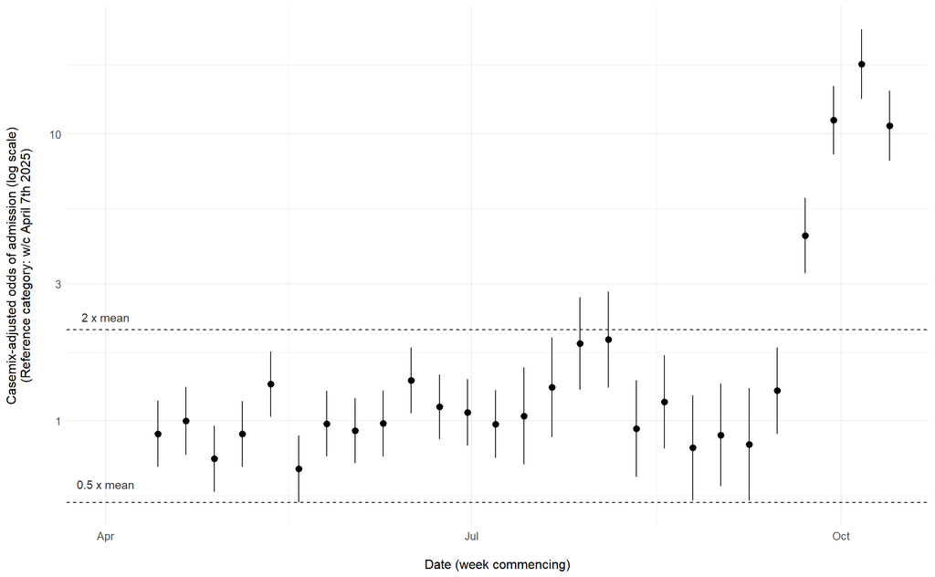

## Presentation of results

In Figure 2, we have illustrated how the odds of admission vary over time with the aid of a particular type of Statistical Process Control (SPC) chart - the XMR chart. This chart has two components, the “X” plot and the “mR” plot:

- The “X” plot (at the top of the chart) displays how the outcome of interest changes over time. Three horizontal lines represent the mean value and the upper and lower “control limits” (at 3 standard deviations from the mean value).[^9] These control limits define the expected range of variation for the process in question. If a point falls between the upper and lower control limits, then the result is considered within the bounds of natural - or “common cause” - variation, and the process is deemed stable. If, on the other hand, a point is outside the control limits, this indicates that the difference from the process mean should not be attributed to random variation. In SPC terms, there is a “special cause” for the variation.[^10]
- The “mR” (moving range) plot, is displayed below the X plot, on an identical horizontal axis. It shows whether the (absolute) difference between consecutive points on the X plot might be considered abnormal. Horizontal lines on the plot show the mean value and the upper control limit (at 3 standard deviations from the mean).[^11] A large change - positive or negative - between consecutive points in the X plot may result in an mR point that is above the upper control limit. In this case, the change in the outcome of interest (between consecutive points) is greater than might be expected for this process.

<sup>9</sup> To obtain control limits with the standard calculations, we must have values that are normally distributed. We therefore performed these calculations on the the raw model output values (log odds ratios), which are approximately normal, and only then transformed them.

<sup>11</sup> Note that differences are absolute, so there is no lower control limit.

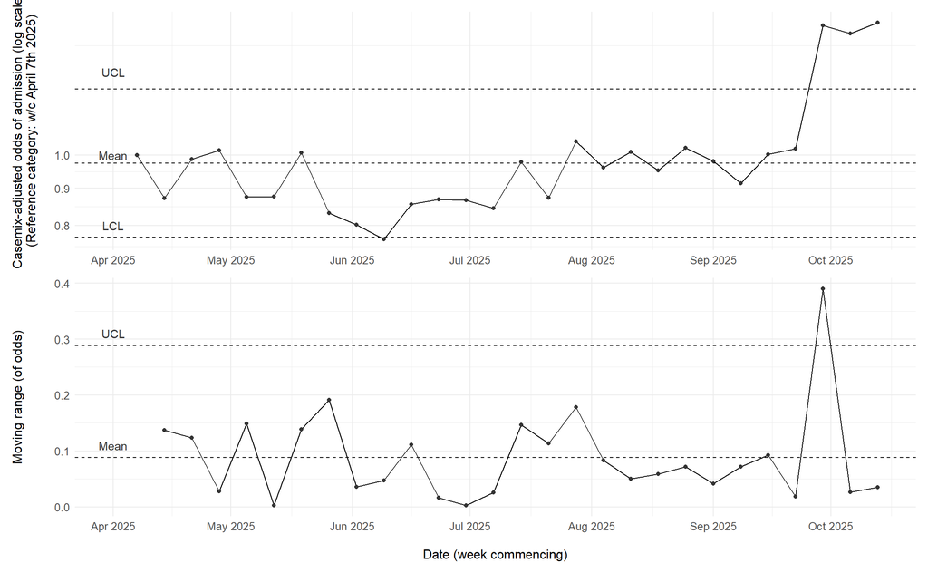

Returning to our specific case, XmR charts may prove useful if we wish to see whether an intervention, or series of interventions,[^12] has had a significant and sustained influence on admission thresholds.

<sup>12</sup> Such as we might see as a consequence of the NHS neighbourhood plan

Looking at Figure 2, which shows St George’s Hospital, it appears (from the X plot) that the casemix-adjusted odds of admission were relatively consistent from April until the last week in September. At this point, the odds of admission rise sharply (which corresponds to a fall in the threshold for admission). What should we read into this?

Firstly, we see that, from the end of September, there is clear evidence of special-cause variation. This indicates the existence of unique or unusual factors influencing the admission threshold at that time, that are not normally present. The mR plot can give us an indication of the nature of these unusual factors. That is to say that, since the weekly change at the end of September is highly abnormal, the special cause variation in the X plot is likely to be the result of an isolated, quickly-appearing event, rather than a initiative that has produced change over an extended period.

Given this context, one of the most likely causes here is a data quality issue. And, if we progress to Figure 3 - which includes information about weeks affected by non-constant risk - we find that non-constant risks *are* flagged in the last few weeks of the period. In this case, then, we should question the validity of these final data points. If we were to re-run the analysis at a later date (as one might, were these methods incorporated into a tool) it is possible that refreshed data would give us a more robust picture of the admission threshold in late September and early October.

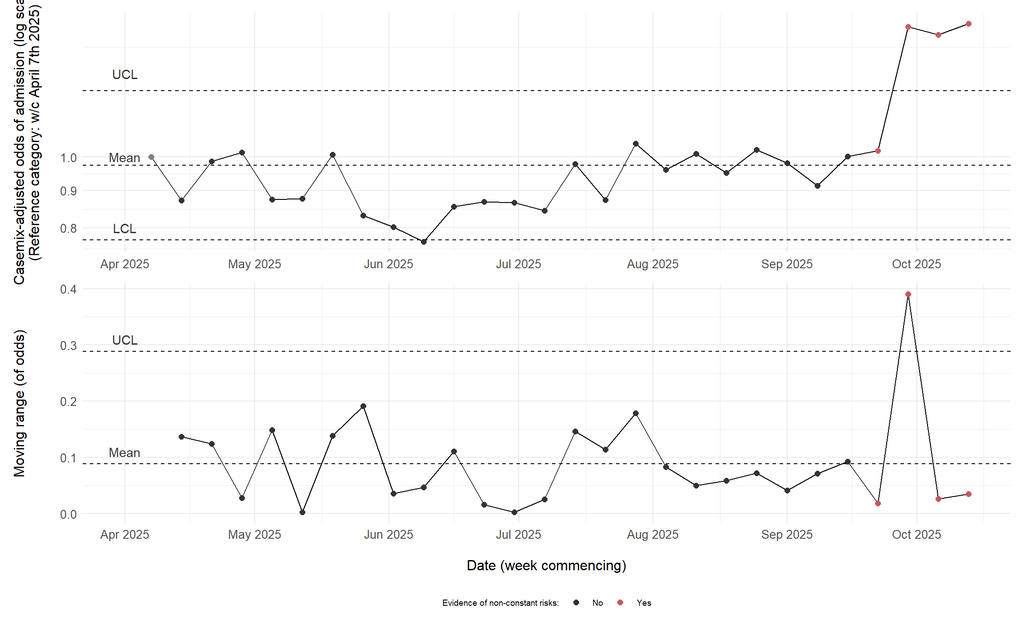

## Reproducibility

The computer code used in this analysis can be found a [GitHub repository](https://github.com/The-Strategy-Unit/tracking_adm_thresholds) (permissions currently required).

# Conclusion

In this document, we have outlined methods and visualisations that would allow local areas to monitor whether casemix-adjusted admission thresholds at their EDs are changing over time.

We suggest that many of the tables and charts presented here might be incorporated in a simple software application (app). Using this app, a user could choose any one of 180 EDs, view the current admission threshold at an ED, and examine how the threshold has changed over time.